# FigureYa183condSurv

**Author(s)**: Xiaofan Lu  
**Reviewer(s)**: Ying Ge, Junyi Shen  
**Date**: `r Sys.Date()`

# Academic Citation

If you use this code in your work or research, we kindly request that you cite our publication:

Xiaofan Lu, et al. (2025). FigureYa: A Standardized Visualization Framework for Enhancing Biomedical Data Interpretation and Research Efficiency. iMetaMed. https://doi.org/10.1002/imm3.70005

# 需求描述

# Requirement

想画条件生存曲线，conditional survival，R包condsurv能实现。 To draw a conditional survival curve, the R package condsurv can achieve conditional survival.

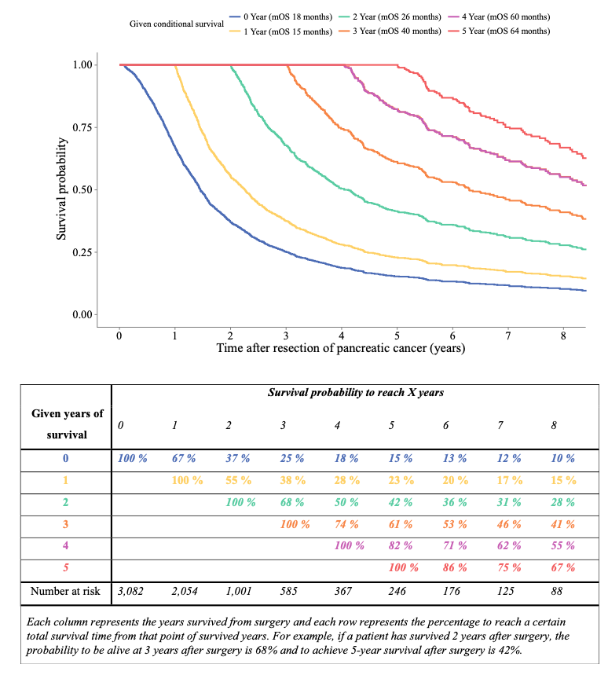

出自https://link.springer.com/article/10.1245/s10434-020-08235-w fromhttps://link.springer.com/article/10.1245/s10434-020-08235-w

# 应用场景

# Application Scenarios

绘制条件概率生存曲线，给出条件生存概率表。 Draw the conditional probability survival curve and provide the conditional survival probability table.

# 环境设置

# Environment Setup

```r
source("install_dependencies.R")
```

```
## Starting R package installation...
## ===========================================
##
## Installing CRAN packages...
## Installing CRAN package: condsurv
```

[output not shown]

```r
options(warn = -1)

#library(condsurv) # 本代码使用的函数为该函数包中gg_conditional_surv的修改版 #The function used in this code is a modified version of gg_conditional_surv in the function package
library(survival)
library(tidyverse)
library(survminer)
library(ggpubr)
library(patchwork)
Sys.setenv(LANGUAGE = "en") #显示英文报错信息  # Display an English error message
options(stringsAsFactors = FALSE) #禁止chr转成factor   # prohibit chr from being converted to factor
```

自定义函数 Custom function

```r
conditional_surv_est <- function(basekm, t1, t2) {
  if (class(basekm) != "survfit") {
    stop(
      "Argument to basekm must be of class survfit"
    )
  }

  if (max(t1) > max(basekm$time)) {
    stop(
      paste(
        "Argument to t1 specifies a value outside the range of observed times;", "the maximum observed time is", round(max(basekm$time), 2)
      )
    )
  }

  if (max(t2) > max(basekm$time)) {
    stop(paste(
      "Argument to t2 specifies a value outside the range of observed times;",
      "the maximum observed time is", round(max(basekm$time), 2)
    ))
  }

  cs <- summary(basekm, times = c(t1, t2))$surv[2] /
    summary(basekm, times = c(t1, t2))$surv[1]
  cs.sq <- cs^2

  d <- basekm$n.event[basekm$time >= t1 &
                        basekm$time <= t2 &
                        basekm$n.event > 0]

  r <- basekm$n.risk[basekm$time >= t1 &
                       basekm$time <= t2 &
                       basekm$n.event > 0]

  dr <- d / (r * (r - d))
  var.cs <- 1 / (log(cs)^2) * sum(dr)
  ci <- cs^(exp(c(1, -1) * stats::qnorm(0.975) * sqrt(var.cs)))
  ci.cs <- round(ci, 2)

  return(
    list(
      cs_est = round(cs, 2),
      cs_lci = ci.cs[1],
      cs_uci = ci.cs[2]
    )
  )
}

con_prob <- function(i){
  y <- as.numeric(i)
  table=purrr::map_df(
    prob_times,
    ~conditional_surv_est(
      basekm = myfit,
      t1 = y,
      t2 = .x)) %>%
    mutate(years = prob_times) %>%
    select(years, everything())
  table$con=i
  table$label=ifelse(table$years<y,NA,paste0((table$cs_est)*100,"%"))
  data.frame(table)
}

plot_condsurv <- function (survdt = NULL,
                           at,
                           surv.cut = NULL,
                           main = "",
                           xlab = "Time (Years)",
                           ylab = "Survival probability",
                           curv.col = NULL,
                           lwd = 1.2,
                           legend.pos = "top")
{
  # survdat: 生存数据，至少包含两列，生存时间（futime，年为单位）和生存状态（fustat）
  # survdat: Survival data, at least two columns, survival time (futime, in years) and survival status (fustat)
  # at：一个数值序列，表示条件生存时间中的附加时间，如在第三年存活的基础上额外存活at年的概率
  # at: A numerical sequence representing additional time in conditional survival time, such as the probability of surviving for an extra at years on top of surviving in the third year
  # surv.cut：KM曲线在surv.cut处截断
  # surv.cut: The KM curve cuts off at surv.cut
  # main：图像主题，默认无
  # main: Image theme, none by default
  # xlab：图像x轴名称，默认以年为单位
  # xlab: Image X-axis name, default in years
  # ylab：图像y轴名称，默认以25%为间隔
  # ylab: Y-axis name of the image, with a default interval of 25%
  # curv.col：各条件生存曲线的颜色
  # curv.col: The color of the survival curve for each condition
  # lwd：线条宽度
  # lwd: Line width
  # legend.pos：图例位置，默认为顶部
  # Legend.pos: legend location, default to top

  library(ggplot2)
  library(survival)
  library(tidyverse)

  basekm <- survfit(Surv(futime, fustat)~ 1, data=survdt, type="kaplan-meier", error="greenwood", conf.type="plain", na.action=na.exclude)

  if (max(at) > max(basekm$time)) {
    stop(paste("Argument to at specifies value(s) outside the range of observed times;",
               "the maximum observed time is", round(max(basekm$time), 2)))
  }
  if(surv.cut <= max(at)) {
    stop("Time cutoff should be greater than the maximal conditional survival point\n")
  }
  if(!all(is.element(c("fustat","futime"),colnames(survdt)))) {
    stop("Make sure the survival data has two columns of fustat and futime\n")
  }

  nt <- length(at)
  fitkm <- list()
  fitkmdat <- list()
  for (i in 1:nt) {
    fitkm[[i]] <- survival::survfit(formula = stats::as.formula(basekm$call$formula),
                                    data = eval(basekm$call$data), start.time = at[i])
    fitkmdat[[i]] <- tibble::tibble(timept = fitkm[[i]]$time,
                                    prob = fitkm[[i]]$surv)
  }
  condsurvdat <- fitkmdat %>% purrr::map_df(`[`, .id = "which_at") %>%
    dplyr::mutate(condtime = factor(which_at, levels = seq(1, nt), labels = at))

  condsurvdat$condtime <- paste0(condsurvdat$condtime," Year")

  # 第一幅条件生存概率曲线
  # The first conditional survival probability curve
  if(is.null(surv.cut)) {
    condsurv_plot <- ggplot(condsurvdat, aes(x = timept, y = prob, color = condtime)) +
                            scale_color_manual(values = mycol) +
                            geom_step(lwd = lwd) +
                            ylim(0, 1) +
                            labs(x = xlab, y = ylab, title = main, color = "Given conditional survival") +
                            geom_segment(aes(x = 0, y = 1, xend = at[length(at)], yend = 1),lwd = lwd, color = curv.col[at[length(at)] + 1]) +
                            theme_classic() +
                            theme(axis.text.x = element_text(angle = 0, hjust = 1, size = 12),
                                  panel.border = element_rect(colour = "black", fill=NA, size=0.2),
                                  axis.ticks = element_line(size=0.2, color="black"),
                                  axis.ticks.length = unit(0.2, "cm"),
                                  legend.position = legend.pos,
                                  axis.title = element_text(size = 15),
                                  axis.text = element_text(size = 10))
    ggsave("conditional_survival_curve.pdf")

  } else {
    condsurv_plot <- ggplot(condsurvdat, aes(x = timept, y = prob, color = condtime)) +
                            scale_color_manual(values = mycol) +
                            geom_step(lwd = lwd) +
                            ylim(0, 1) +
                            xlim(0, surv.cut) +
                            labs(x = xlab, y = ylab, title = main, color = "Given conditional survival") +
                            geom_segment(aes(x = 0, y = 1, xend = at[length(at)], yend = 1),lwd = lwd, color = curv.col[at[length(at)] + 1]) +
                            theme_classic() +
                            theme(axis.text.x = element_text(angle = 0, hjust = 1, size = 12),
                                  panel.border = element_rect(colour = "black", fill=NA, size=0.2),
                                  axis.ticks = element_line(size=0.2, color="black"),
                                  axis.ticks.length = unit(0.2, "cm"),
                                  legend.position = legend.pos,
                                  axis.title = element_text(size = 15),
                                  axis.text = element_text(size = 10))
  }

  # 输出条件生存概率表
  # Output the conditional survival probability table
  condsurvmat <- matrix("",
                        nrow = max.condsurv + 1,
                        ncol = floor(max(survdt$futime)) + 1,
                        dimnames = list(paste0("y",0:max.condsurv),
                                         paste0("y",0:floor(max(survdt$futime)))))
  condsurvmat <- as.data.frame(condsurvmat)

  for (given_year in 0:max.condsurv) {
    for (reach_year in given_year:floor(max(survdt$futime))) {
      condsurvmat[paste0("y",given_year),paste0("y",reach_year)] <-
        paste0(conditional_surv_est(basekm, given_year, reach_year)$cs_est * 100,"%")
    }
  }
  write.csv(condsurvmat,file = "conditional_survival_matrix.csv",row.names = T,col.names = NA,quote = F)

  return(list(condsurvdat = condsurvdat, condsurvcurve = condsurv_plot, condsurvmat = condsurvmat, cond = at, prob_times = seq(0,surv.cut,1), basekm = basekm))
}
```

# 输入文件

# Input File

easy_input.csv，生存数据，至少包含两列，生存时间（futime，年为单位）和生存状态（fustat）。 easy_input.csv, survival data, must contain at least two columns: survival time (futime, in years) and survival status (fustat).

```r
dat <- read.csv("easy_input.csv",row.names = NULL,check.names = F,stringsAsFactors = F, header = T)
head(dat)
```

```
##   futime fustat
## 1   2178      0
## 2   2172      0
## 3   2190      0
## 4    297      1
## 5   2131      0
## 6      1      1
```

```r
table(dat$fustat)
```

```
##
##   0   1
## 285 215
```

# 分析画图

# Analysis drawing

原文上半部分是图，下半部分是表格。 The upper part of the original text is a graph and the lower part is a table.

这里都用画图的方式实现，让三部分结果对齐。当然你也可以像原文那样画成表格。 Here, all are achieved through drawing diagrams to align the results of the three parts. Of course, you can also draw it as a table just like in the original text.

```r
# 注意将生存时间转换为年
# Note to convert the survival time to years
dat$futime <- dat$futime/365

# 设置最长希望观测的生存时间点（条件概率的最大生存时间，如5年）
# Set the maximum desired survival time point for observation (the maximum survival time of conditional probability, such as 5 years)
max.condsurv <- 5

# 自定义颜色
# Custom Colors
mycol <- RColorBrewer::brewer.pal(n = max.condsurv + 1, name = 'Set2')

# 第一幅
# The First One
# 调用函数画图，同时输出生存概率表
# Call the function to draw a graph and output the survival probability table at the same time
p1 <- plot_condsurv(survdt = dat,
                   at = 0:max.condsurv,
                   surv.cut = 6,
                   curv.col = mycol,
                   legend.pos = "top")

# 第二幅
# The Second One
# 把条件生存概率表画成图
# Plot the conditional survival probability table as a graph
myfit <- p1$basekm
cond <- p1$cond
prob_times <- p1$prob_time
data <- do.call(rbind,lapply(cond, con_prob))
data$years <- as.factor(data$years)
p2 <- ggplot(data = data, aes(x=years,y=con,label=label))+
        ggpubr::geom_exec(geom_text, data = data, size = 5, color = "con")+
        scale_y_reverse()+theme_classic()+
        theme(legend.position = "none",
           axis.text.x = element_text(size=15),
           axis.text.y = element_text(size=15),
           axis.title = element_text(size=15))+
        xlab("Survival probability to reach X years")+
        ylab("Given years of survival") +
        scale_color_gradientn(colours = mycol) #颜色跟第一幅图一致

# 第三幅
# The Third One
n <- ggrisktable(myfit, break.time.by=1, data = dat)
```

```
## Ignoring unknown labels:
## • colour : "Strata"
```

```r
m <- n$data[(min(prob_times)+1):(max(prob_times)+1),]
m$time <- as.factor(m$time)
# 把风险表输出到文件
# Output the risk table to a file
risk <- t(data.frame(risk = m$n.risk))
colnames(risk) <- m$time
write.csv(risk, "number_at_risk.csv", quote = F)
# 把风险表画成图
# Draw the risk table as a graph
p3 <- ggplot(data = m, aes(x=time, y=strata, label=n.risk)) +
  ggpubr::geom_exec(geom_text, data = m, size = 5, color = "black") +
  theme_classic() +
  theme(legend.position = "none",
        axis.text.x = element_text(size=15),
        axis.text.y = element_text(size=15),
        axis.title = element_text(size=15)) +
  ylab("Number at risk") +
  xlab("Years")
```

合并图像并输出 Merge the images and output them

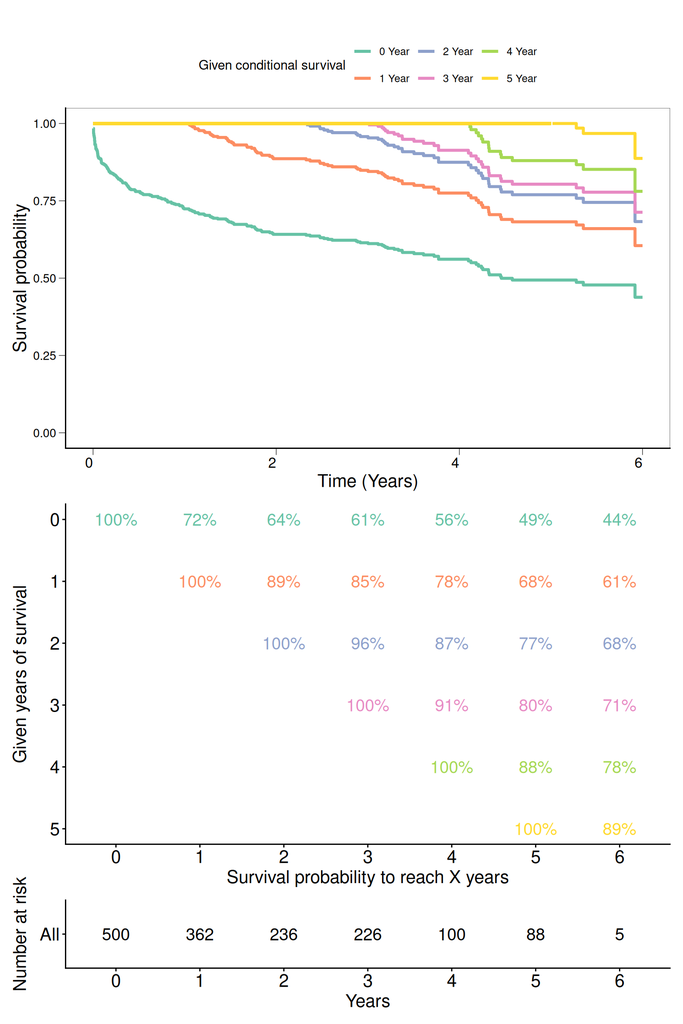

```r
condsurv_plot <- p1$condsurvcurve + p2 + p3 +
  plot_layout(ncol = 1, heights = c(5,5,1))
condsurv_plot
```

```r
ggsave("conditional_survival_curve.pdf", width = 8, height = 12)
```